# Homework 3

Author

Kendall Dimson

```r
#Set-up
options(repos = c(CRAN = "https://cloud.r-project.org/"))
install.packages("tidytext", quiet = TRUE)
install.packages("textdata", quiet = TRUE)
install.packages("data.table", quiet = TRUE)

library(data.table)
library(textdata)
library(readr)
library(dplyr)
library(tidyverse)
library(tidytext)

# Read in Data
abstract <- fread("https://raw.githubusercontent.com/USCbiostats/data-science-data/refs/heads/master/03_pubmed/pubmed.csv")
```

## Text Mining

### Question 1

Tokenize the abstracts and count the number of each token. Do you see anything interesting? Does removing stop words change what tokens appear as the most frequent? What are the 5 most common tokens for each search term after remocing stopwords?

```r
abstract |>
  unnest_tokens(token, abstract) |>
  count (token, sort=TRUE) |>
  top_n(5,n)
```

```
    token     n
   <char> <int>
1:    the 28126
2:     of 24760
3:    and 19993
4:     in 14653
5:     to 10920
```

```r
abstract |>
 unnest_tokens(token, abstract) |>
  anti_join(stop_words, by = c("token" = "word")) |>
  filter(!str_detect(token, "^[0-9]+$")) |>
  count(token, sort = TRUE) |>
    top_n(5,n)
```

```
      token     n
     <char> <int>
1:    covid  7275
2: patients  4674
3:   cancer  3999
4: prostate  3832
5:  disease  2574
```

```r
#5 most common tokens for each search term
```

The removal of stopwords definitely improves finding the most common tokens, otherwise, the top words in the abstracts are stopwords such as “the,” “and,” etc. Overall, the most common tokens are “covid” (n=7275), “patients” (n=4674), “cancer” (n=3999), “prostate” (n=3832), and “disease” (n=2574).

```r
table(abstract$term)
```

```
          covid cystic fibrosis      meningitis    preeclampsia prostate cancer
            981             376             317             780             787
```

```r
#Search terms: "covid" "cystic fibrosis" "meningitis" "preeclampsia" "prostate cancer"
```

```r
covid <- abstract |> filter(term=='covid')
covid |>
 unnest_tokens(token, abstract) |>
  anti_join(stop_words, by = c("token" = "word")) |>
  filter(!str_detect(token, "^[0-9]+$")) |>
  count(token, sort = TRUE) |>
    top_n(5,n)
```

```
         token     n
        <char> <int>
1:       covid  7275
2:    patients  2293
3:     disease   943
4:    pandemic   800
5: coronavirus   647
6:      health   647
```

In the search term, “covid,” after removing the stop words, the five most common tokens are: “covid” (n=7275), “patients” (n=2293), “disease” (n=943), “pandemic” (n=800), and the words “coronavirus” and “health” are tied for fifth-most common (n=647).

```r
cf <- abstract |> filter(term=='cystic fibrosis')
cf |>
 unnest_tokens(token, abstract) |>
  anti_join(stop_words, by = c("token" = "word")) |>
  filter(!str_detect(token, "^[0-9]+$")) |>
  count(token, sort = TRUE) |>
    top_n(5,n)
```

```
      token     n
     <char> <int>
1: fibrosis   867
2:   cystic   862
3:       cf   625
4: patients   586
5:  disease   400
```

In the search term, “cystic fibrosis,” after removing the stop words, the five most common tokens are:“fibrosis” (n=867), “cystic” (n=862), “cf” (n=625), “patients” (n=586), and “disease” (n=400).

```r
meningitis <- abstract |> filter (term=='meningitis')
meningitis |>
 unnest_tokens(token, abstract) |>
  anti_join(stop_words, by = c("token" = "word")) |>
  filter(!str_detect(token, "^[0-9]+$")) |>
  count(token, sort = TRUE) |>
    top_n(5,n)
```

```
        token     n
       <char> <int>
1:   patients   446
2: meningitis   429
3:  meningeal   219
4:        csf   206
5:   clinical   187
```

In the search term, “meningitis,” after removing the stop words, the five most common tokens are:“patients” (n=446), “meningitis” (n=429), “meningeal” (n=219), “csf” (n=206), and “clinical” (n=187).

```r
preeclampsia <- abstract |> filter (term=='preeclampsia')
preeclampsia |>
 unnest_tokens(token, abstract) |>
  anti_join(stop_words, by = c("token" = "word")) |>
  filter(!str_detect(token, "^[0-9]+$")) |>
  count(token, sort = TRUE) |>
    top_n(5,n)
```

```
          token     n
         <char> <int>
1:          pre  2038
2:    eclampsia  2005
3: preeclampsia  1863
4:        women  1196
5:    pregnancy   969
```

In the search term, “preeclampsia,” after removing the stop words, the five most common tokens are:“pre” (n=2038), “eclampsia” (n=2005), “preeclampsia” (n=1863), “women” (n=1196), and “pregnancy” (n=969).

```r
prostate <- abstract |> filter (term=='prostate cancer')
prostate |>
 unnest_tokens(token, abstract) |>
  anti_join(stop_words, by = c("token" = "word")) |>
  filter(!str_detect(token, "^[0-9]+$")) |>
  count(token, sort = TRUE) |>
    top_n(5,n)
```

```
       token     n
      <char> <int>
1:    cancer  3840
2:  prostate  3832
3:  patients   934
4: treatment   926
5:   disease   652
```

In the search term, “prostate cancer,” after removing the stop words, the five most common tokens are:“cancer” (n=3840), “prostate” (n=3832), “patients” (n=934), “treatment” (n=926), and “disease” (n=652).

### Question 2

Tokenize the abstracts into bigrams. Find the 10 most common bigrams and visualize them with ggplot2.

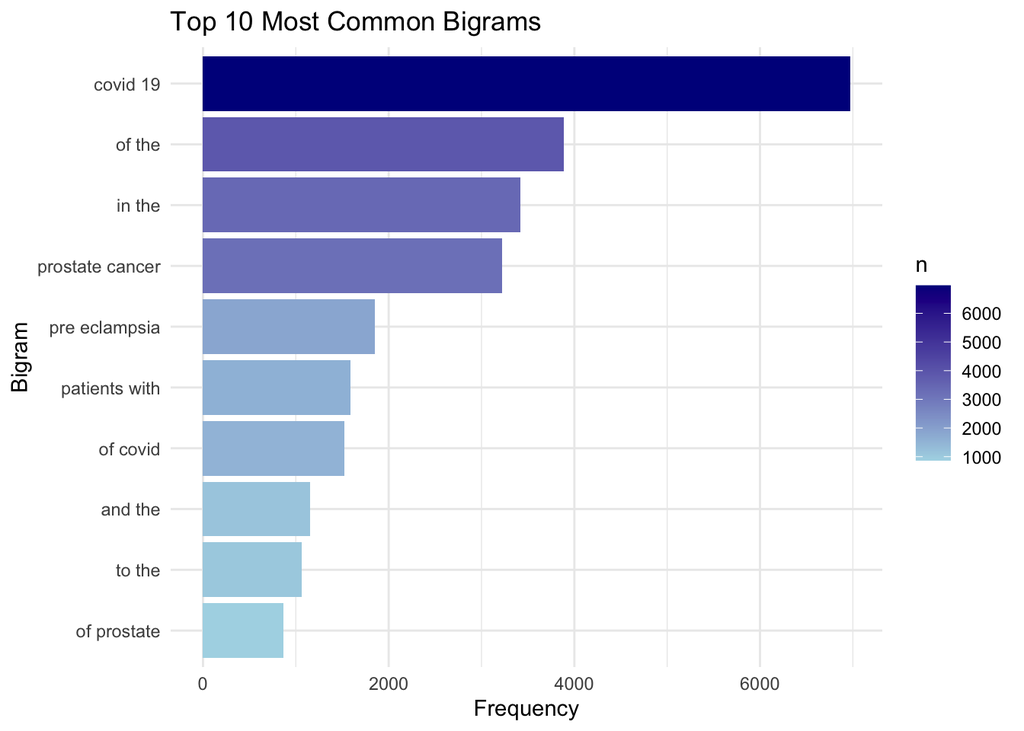

```r
abstract |>
  unnest_ngrams(ngram, abstract, n = 2) |>
  count(ngram, sort = TRUE) |>
  slice_max(order_by = n, n = 10) |>
  ggplot(aes(x = n, y = fct_reorder(ngram, n), fill=n)) +
  geom_col() +  scale_fill_gradient(low = "lightblue", high = "darkblue")+ labs(
    x = "Frequency",
    y = "Bigram",
    title = "Top 10 Most Common Bigrams"
  ) +
  theme_minimal()
```

### Question 3

Calculate the TF-IDF value for each word-search term combination (here you want the search term to be the “document”). What are the 5 tokens from each search term with the highest TF-IDF value? How are the results different from the answers you got in question 1?

```r
tfidf <- abstract |>
  unnest_tokens(token, abstract) |>
  anti_join(stop_words, by = c("token" = "word")) |>
  filter(!str_detect(token, "^[0-9]+$")) |>
  count(term, token, sort = TRUE) |>
  bind_tf_idf(token, term, n) |>
    group_by(term) |>
    top_n(5, tf_idf)|>
    arrange(term, -tf_idf)
```

The five tokens from each search term with the highest TF-IDF value, comparing to Question 1:

COVID: Question 1: patients, disease, pandemic, coronavirus, health

Question 3 (top 5 tokens with highest TF-IDF value): covid, pandemic, coronavirus, sars, cov

New words replaced: sars, cov

```r
#Covid
tfidf|> filter(term=='covid')
```

```
# A tibble: 5 × 6
# Groups:   term [1]
  term  token           n      tf   idf  tf_idf
  <chr> <chr>       <int>   <dbl> <dbl>   <dbl>
1 covid covid        7275 0.0722   1.61 0.116
2 covid pandemic      800 0.00794  1.61 0.0128
3 covid coronavirus   647 0.00642  1.61 0.0103
4 covid sars          372 0.00369  1.61 0.00594
5 covid cov           334 0.00331  1.61 0.00533
```

```r
#Cystic Fibrosis
tfidf|> filter(term=='cystic fibrosis')
```

```
# A tibble: 5 × 6
# Groups:   term [1]
  term            token        n      tf   idf  tf_idf
  <chr>           <chr>    <int>   <dbl> <dbl>   <dbl>
1 cystic fibrosis cf         625 0.0242  0.916 0.0222
2 cystic fibrosis fibrosis   867 0.0336  0.511 0.0172
3 cystic fibrosis cystic     862 0.0334  0.511 0.0171
4 cystic fibrosis cftr        86 0.00333 1.61  0.00536
5 cystic fibrosis sweat       83 0.00321 1.61  0.00517
```

Question 1: fibrosis, cystic, cf, patients, disease

Question 3 (top 5 tokens with highest TF-IDF value): cf, fibrosis, cystic, cftr, sweat

New words replaced: cftr, sweat

```r
#meningitis
tfidf|> filter(term=='meningitis')
```

```
# A tibble: 5 × 6
# Groups:   term [1]
  term       token               n      tf   idf  tf_idf
  <chr>      <chr>           <int>   <dbl> <dbl>   <dbl>
1 meningitis meningitis        429 0.0172  1.61  0.0278
2 meningitis meningeal         219 0.00880 1.61  0.0142
3 meningitis pachymeningitis   149 0.00599 1.61  0.00964
4 meningitis csf               206 0.00828 0.916 0.00759
5 meningitis meninges          106 0.00426 1.61  0.00686
```

Question 1:patients, meningitis, meningeal, csf, clinical

Question 3 (top 5 tokens with highest TF-IDF value): meningitis, meningeal, pachymeningitis, csf, meninges

new words replaced: pachymeningitis, meninges

```r
#Preeclampsia
tfidf|> filter(term=='preeclampsia')
```

```
# A tibble: 5 × 6
# Groups:   term [1]
  term         token            n      tf   idf  tf_idf
  <chr>        <chr>        <int>   <dbl> <dbl>   <dbl>
1 preeclampsia eclampsia     2005 0.0267  1.61  0.0429
2 preeclampsia preeclampsia  1863 0.0248  1.61  0.0399
3 preeclampsia pregnancy      969 0.0129  0.511 0.00659
4 preeclampsia maternal       797 0.0106  0.511 0.00542
5 preeclampsia gestational    191 0.00254 1.61  0.00409
```

Question 1:pre, eclampsia, preeclampsia, women, pregnancy

Question 3 (top 5 tokens with highest TF-IDF value): eclampsia, preeclampsia, pregnancy, maternal, gestational

new words replaced: maternal, gestational

```r
#Prostate cancer
tfidf|> filter(term=='prostate cancer')
```

```
# A tibble: 5 × 6
# Groups:   term [1]
  term            token             n      tf   idf  tf_idf
  <chr>           <chr>         <int>   <dbl> <dbl>   <dbl>
1 prostate cancer prostate       3832 0.0577   1.61 0.0929
2 prostate cancer androgen        305 0.00459  1.61 0.00739
3 prostate cancer psa             282 0.00425  1.61 0.00683
4 prostate cancer prostatectomy   215 0.00324  1.61 0.00521
5 prostate cancer castration      148 0.00223  1.61 0.00359
```

Question 1: cancer, prostate, patients, treatment, disease

Question 3 (top 5 tokens with highest TF-IDF value): prostate, androgen, psa, prostatectomy, castration’

new words replaced: androgen, psa, prostatectomy, castration

Overall, terms such as “disease,” “patients,” “health,” treatment,” and “disease” have a high frequency but low TF-IDF, such that they don’t contribute as much to the overall meaning of the abstracts. In the tokens of each search term with the highest TF-IDF, they are more related to the topics and makes it more interpretable.

## Sentiment Analysis

### Question 1

Perform a sentiment analysis using the NRC lexicon. What is the most common sentiment for each search term? What if you remove “positive” and “negative” from the list?

```r
# Sentiment Analysis #1
sentiment_analysis <- abstract |>
  unnest_tokens(word, abstract) |>
  inner_join(get_sentiments("nrc"), by = "word") |>
  group_by(term) |>
  summarise(sentiment = names(which.max(table(sentiment))))
print(sentiment_analysis)
```

```
# A tibble: 5 × 2
  term            sentiment
  <chr>           <chr>
1 covid           positive
2 cystic fibrosis positive
3 meningitis      negative
4 preeclampsia    positive
5 prostate cancer negative
```

```r
# sentiment analysis #2, excluding "positive" and "negative"
sentiment_analysis_2 <- abstract |>
  unnest_tokens(word, abstract) |>
  inner_join(get_sentiments("nrc"), by = "word") |>
  filter(sentiment != c("positive", "negative")) |>
  group_by(term) |>
  summarise(sentiment = names(which.max(table(sentiment))))
print(sentiment_analysis_2)
```

```
# A tibble: 5 × 2
  term            sentiment
  <chr>           <chr>
1 covid           fear
2 cystic fibrosis disgust
3 meningitis      fear
4 preeclampsia    anticipation
5 prostate cancer fear
```

Covid, cystic fibrosis, and preeclampsia have a positive sentiment. Meningitis and prostate cancer have a negative sentiment.

When filtering to exclude ‘positive’ and ‘negative,’ covid, meningitis, and prostate cancer’s overall sentiment is ‘fear’. Cystic fibrosis overall sentiment is ‘disgust.’ Preeclampsia’s overall sentiment is ’anticipation.” When removing “positive” and “negative” it gives a much more interesting analysis on the connotation of words used in the abstracts on each term topic.

### Question 2

Now perform a sentiment analysis using the AFINN lexicon to get an average positivity score for each abstract (hint: you may want to create a variable that indexes, or counts, the abstracts). Create a visualization that shows these scores grouped by search term. Are any search terms noticeably different from the others?

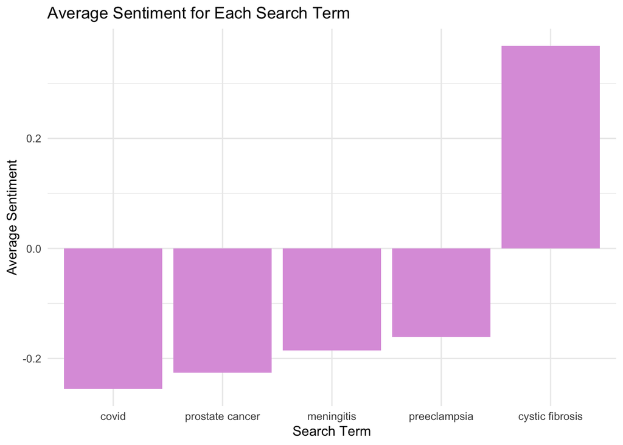

```r
avg_term <- abstract |>
  unnest_tokens(word, abstract) |>
  inner_join(get_sentiments("afinn")) |>
  group_by(term) |>
  summarise(sentiment = mean(value))
ggplot(avg_term, aes(x = reorder(term, sentiment), y = sentiment, fill="plum"))+
  geom_bar(stat = "identity", , fill='plum',show.legend = FALSE) +
  labs(
    x = "Search Term",
    y = "Average Sentiment",
    title = "Average Sentiment for Each Search Term") +
    theme_minimal()
```

Cystic fibrosis is the only search term with a positive sentiment using the afinn lexicon, while the other search terms (covid, prostate cancer, meningitis, preeclampsia) have a negative sentiment with the afinn lexicon.